# Mood Tracker Observations

## Graph 1: How does mood affect self reflection?

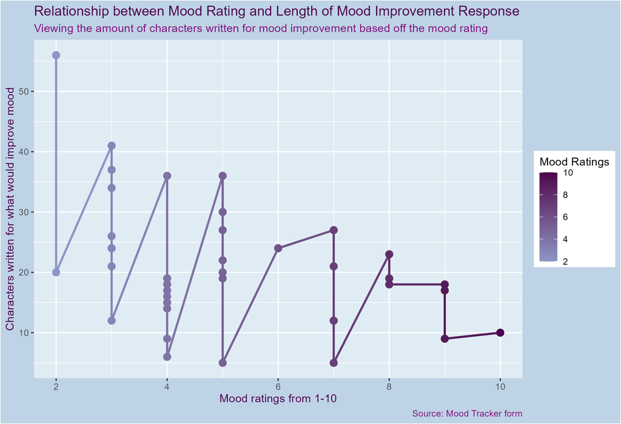

A line and points graph that show the relationship between the mood ratings and the length of the response for the mood improvement question, with a trend of lower mood ratings resulting in longer responses on mood improvement.

- The data collected was my mood recorded over several days, which included rating my mood on a numerical scale from 1-10 and a written reflection on how I believe I could improve my mood. To look for trends, the length of these mood improvement reflections was measured against the mood ratings.
- The graph shows continuous data using two variables, plotted with line and points. The X-axis shows the mood ratings from the responses and the Y-axis the lengths of each response for the mood improvement reflection. From the plot, we see a trend where responses with lower mood rating tend to have a longer response on mood improvement.
- An interpretation of this can be that when people feel worse, there is a tendency to write more and find reasons to help themselves improve their mood.

## Graph 2: Are moods frequently more positive or negative?

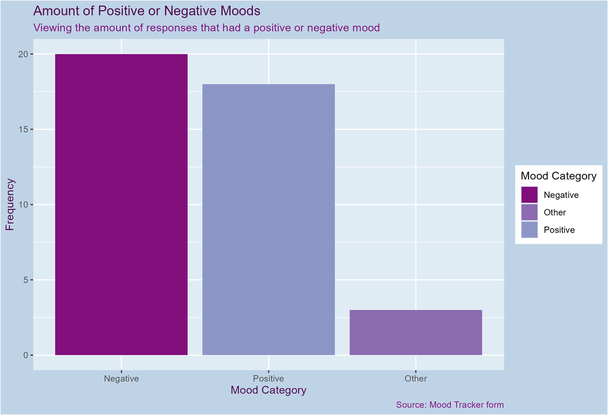

A bar graph that shows the mood responses categorised into positive, negative and other, with a trend of a higher frequency in negative moods.

- I categorised my mood responses into either “Positive”, “Negative” or “Other” moods to analyse the distribution of mood types throughout the duration of the project.
- The plot shows discrete and continuous data on a bar graph. The X-axis shows the mood categories and the Y-axis shows the frequency of those moods recorded. From the plot, we can see that there is a slightly higher frequency of negative moods than positive moods.
- An interpretation of this can be that while the difference is very little, people tend to reflect on their moods more when they are negative and feel more compelled to check in with their emotions as a way to self reflect.

## Graph 3: How do affect energy levels affect mood at different times of the day?

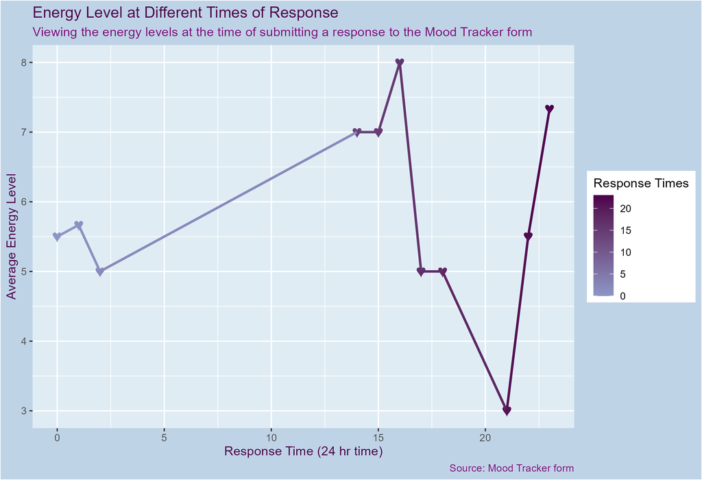

A plot showing the average energy levels at the time of response, with a trend highest energy during the afternoon and lowest during the evening.